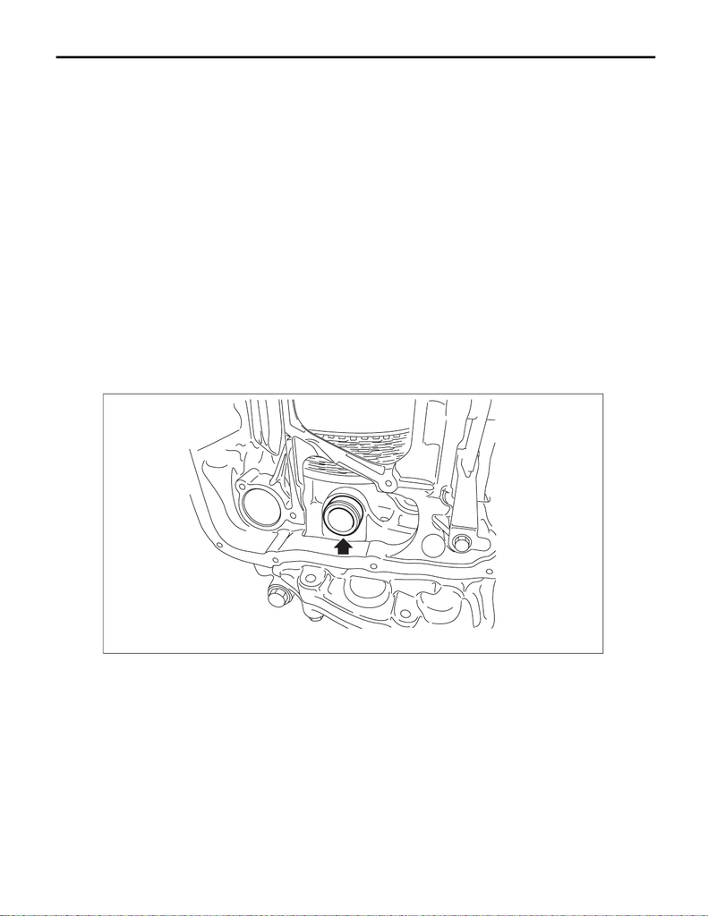

CVT(TR690)-212

Transmission Case

CONTINUOUSLY VARIABLE TRANSMISSION

40.Transmission Case

A: REMOVAL

1) Remove the transmission assembly from the vehicle. <Ref. to CVT(TR690)-56, REMOVAL, Automatic

Transmission Assembly.>

2) Remove the air breather hose. <Ref. to CVT(TR690)-136, REMOVAL, Air Breather Hose.>

3) Remove the transmission harness. <Ref. to CVT(TR690)-123, REMOVAL, Transmission Harness.>

4) Remove the secondary speed sensor. <Ref. to CVT(TR690)-99, REMOVAL, Secondary Speed Sensor.>

5) Remove the inhibitor switch. <Ref. to CVT(TR690)-95, REMOVAL, Inhibitor Switch.>

6) Remove the extension case. <Ref. to CVT(TR690)-142, REMOVAL, Extension Case.>

7) Remove the rear drive shaft. <Ref. to CVT(TR690)-146, REMOVAL, Rear Drive Shaft.>

8) Remove the transfer clutch assembly. <Ref. to CVT(TR690)-151, REMOVAL, Transfer Clutch.>

9) Remove the center differential carrier. <Ref. to CVT(TR690)-154, REMOVAL, Center Differential Carrier.>

10) Remove the transfer reduction driven gear assembly. <Ref. to CVT(TR690)-158, REMOVAL, Transfer

Reduction Driven Gear.>

11) Remove the intermediate case. <Ref. to CVT(TR690)-165, REMOVAL, Intermediate Case.>

12) Remove the forward clutch assembly. <Ref. to CVT(TR690)-181, REMOVAL, Forward Clutch Assem-

bly.>

13) Remove the reduction driven gear. <Ref. to CVT(TR690)-201, REMOVAL, Reduction Driven Gear.>

14) Remove the oil pan and control valve body. <Ref. to CVT(TR690)-112, REMOVAL, Control Valve Body.>

NOTE:

When removing the control valve body, also remove the pressure pipe if it is attached on the case.

AT-05277

15WRX_STI_US_EN.book 212 ページ ２０１５年２月１３日 金曜日 午前１１時２０分

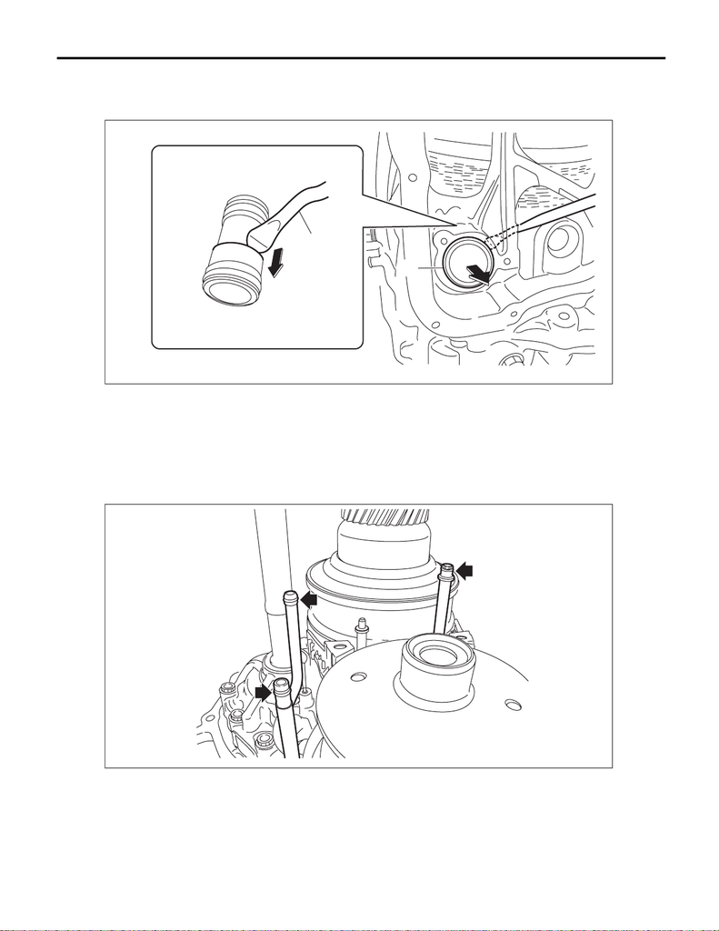

CVT(TR690)-213

Transmission Case

CONTINUOUSLY VARIABLE TRANSMISSION

15) Remove the CVTF pipe using a tire lever etc.

NOTE:

Remove by hooking the stepped portion of CVTF pipe with a tire lever etc.

16) Remove the transmission case.

NOTE:

The total number of transmission case mounting bolts is 15.

17) Remove the O-ring of lubrication pipe.

18) Remove the control device system. <Ref. to CVT(TR690)-208, REMOVAL, Transmission Control De-

vice.>

(A) CVTF pipe

(B) Tire lever

AT-07891AT-0

(A)

(B)

(B)

AT-05279

15WRX_STI_US_EN.book 213 ページ ２０１５年２月１３日 金曜日 午前１１時２０分

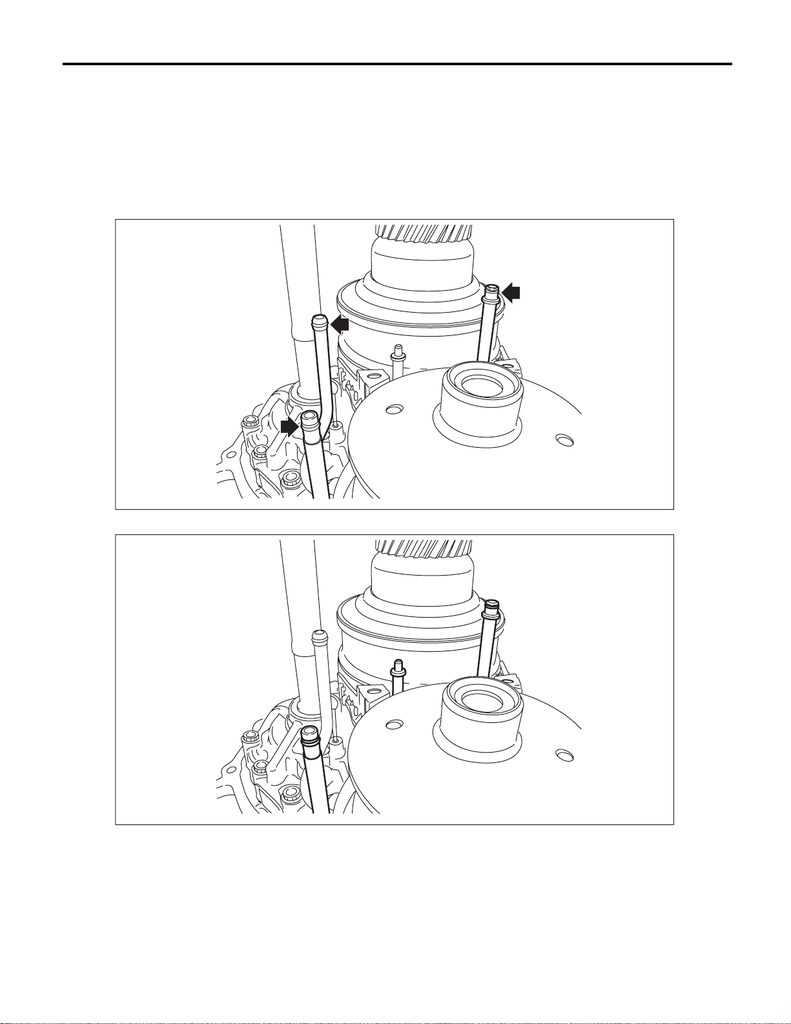

CVT(TR690)-214

Transmission Case

CONTINUOUSLY VARIABLE TRANSMISSION

B: INSTALLATION

1) Clean the mating surface of transmission case and converter case.

2) Install the control device system. <Ref. to CVT(TR690)-210, INSTALLATION, Transmission Control De-

vice.>

3) Install the O-ring to the lubrication pipe.

NOTE:

• Use new O-rings.

• Apply CVTF to the O-rings.

4) Make sure the lubrication pipe and support rod are in vertical position.

AT-05279

AT-05280

15WRX_STI_US_EN.book 214 ページ ２０１５年２月１３日 金曜日 午前１１時２０分

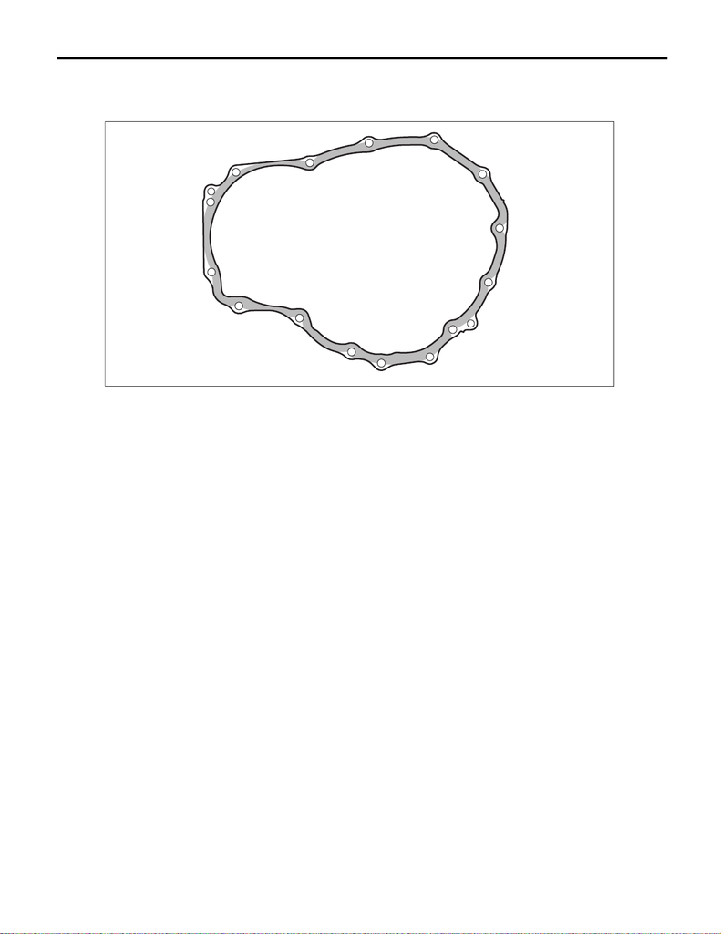

CVT(TR690)-215

Transmission Case

CONTINUOUSLY VARIABLE TRANSMISSION

5) Apply liquid gasket seamlessly to the mating surface of transmission case.

Liquid gasket:

THREE BOND 1215B or equivalent

6) Install the transmission case.

CAUTION:

If the transmission case gets in contact with the lubrication pipe and support rod, do not install the

transmission case forcibly.

NOTE:

• Install while checking the lubrication pipe and support rod is being inserted properly into transmission

case.

• If installing the transmission is difficult, check if the lubrication pipe and support rod are bent.

• The total number of transmission case mounting bolts is 15.

Tightening torque:

41 N·m (4.2 kgf-m, 30.2 ft-lb)

7) Install the O-ring to CVTF pipe.

NOTE:

Use new O-rings.

AT-05281

15WRX_STI_US_EN.book 215 ページ ２０１５年２月１３日 金曜日 午前１１時２０分

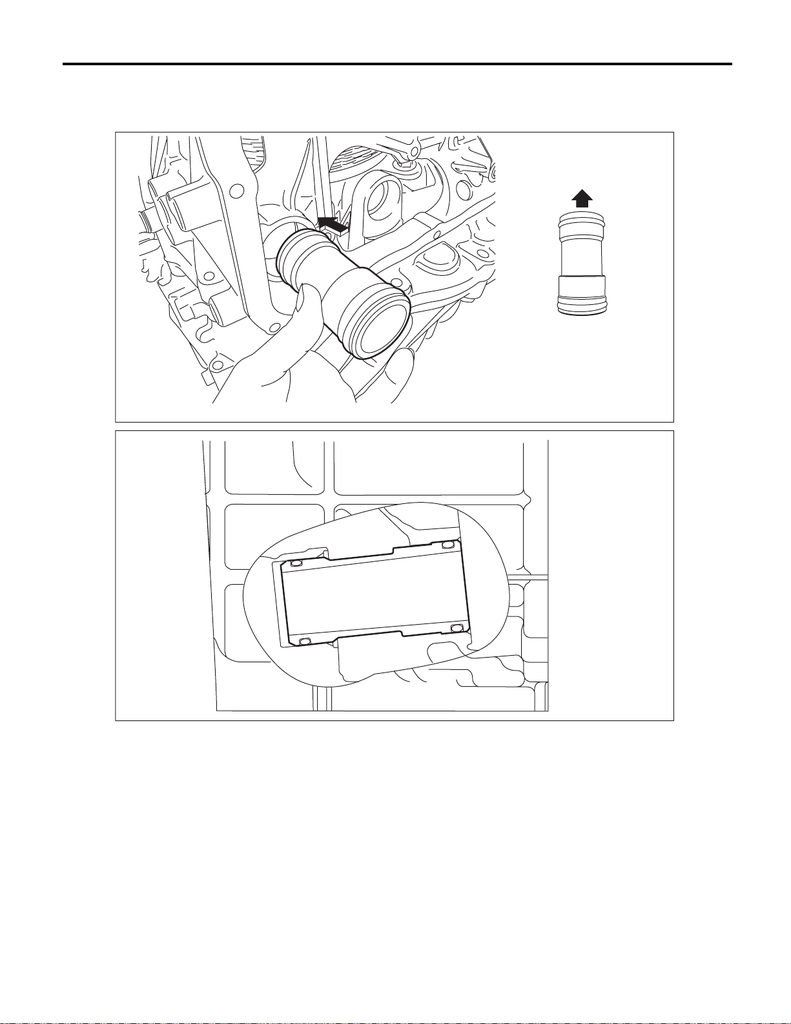

CVT(TR690)-216

Transmission Case

CONTINUOUSLY VARIABLE TRANSMISSION

8) The smaller opening of CVTF pipe should be inserted to transmission.

NOTE:

After installing, make sure the CVTF pipe does not stick out of transmission case.

9) Install the reduction driven gear. <Ref. to CVT(TR690)-202, INSTALLATION, Reduction Driven Gear.>

10) Install the forward clutch assembly. <Ref. to CVT(TR690)-182, INSTALLATION, Forward Clutch Assembly.>

11) Install the intermediate case. <Ref. to CVT(TR690)-166, INSTALLATION, Intermediate Case.>

12) Install the transfer reduction driven gear assembly. <Ref. to CVT(TR690)-158, INSTALLATION, Transfer

Reduction Driven Gear.>

13) Install the center differential carrier. <Ref. to CVT(TR690)-155, INSTALLATION, Center Differential Carrier.>

14) Install the transfer clutch assembly. <Ref. to CVT(TR690)-151, INSTALLATION, Transfer Clutch.>

15) Install the rear drive shaft. <Ref. to CVT(TR690)-146, INSTALLATION, Rear Drive Shaft.>

AT-05282

AT-05588

15WRX_STI_US_EN.book 216 ページ ２０１５年２月１３日 金曜日 午前１１時２０分

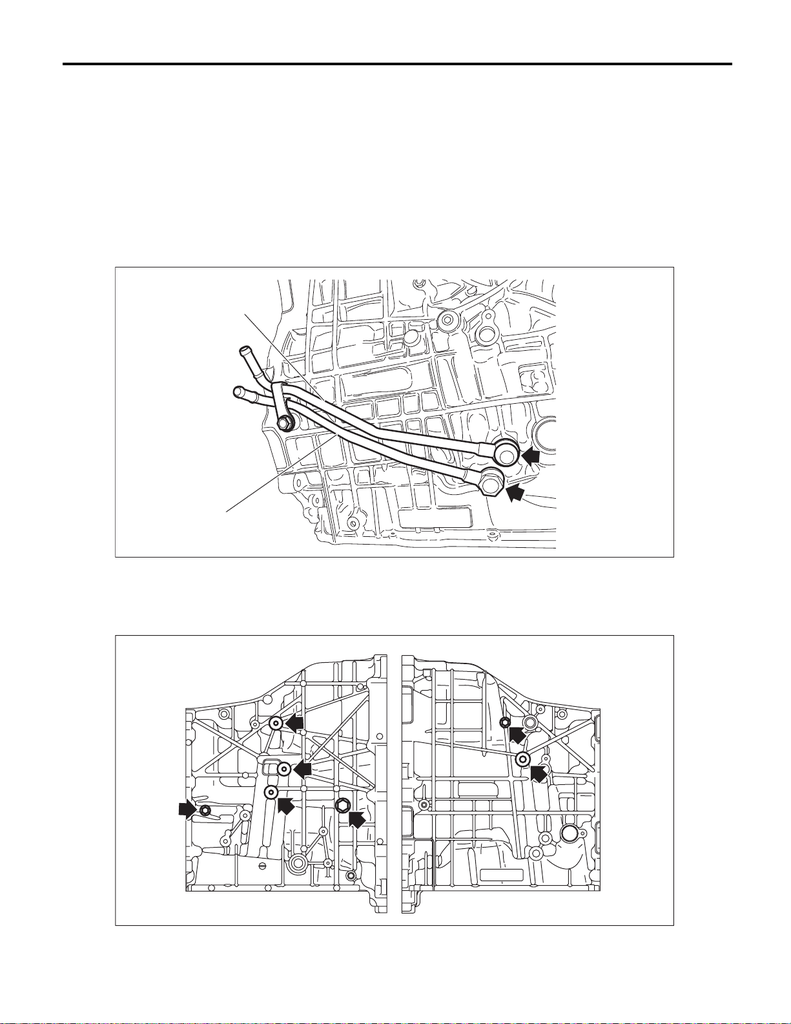

CVT(TR690)-217

Transmission Case

CONTINUOUSLY VARIABLE TRANSMISSION

16) Install the extension case. <Ref. to CVT(TR690)-143, INSTALLATION, Extension Case.>

17) Install the inhibitor switch. <Ref. to CVT(TR690)-97, INSTALLATION, Inhibitor Switch.>

18) Install the secondary speed sensor. <Ref. to CVT(TR690)-100, INSTALLATION, Secondary Speed Sen-

sor.>

19) Install the transmission harness. <Ref. to CVT(TR690)-125, INSTALLATION, Transmission Harness.>

20) Install the control valve body and oil pan. <Ref. to CVT(TR690)-116, INSTALLATION, Control Valve Body.>

21) Install the air breather hose. <Ref. to CVT(TR690)-136, INSTALLATION, Air Breather Hose.>

22) Install the transmission assembly to the vehicle. <Ref. to CVT(TR690)-69, INSTALLATION, Automatic

Transmission Assembly.>

C: DISASSEMBLY

1) Remove the CVTF inlet pipe and CVTF outlet pipe.

2) Remove all plugs from the transmission case.

(A) CVTF outlet pipe

(B) CVTF inlet pipe

CVT00588

(A)

(B)

AT-05283

15WRX_STI_US_EN.book 217 ページ ２０１５年２月１３日 金曜日 午前１１時２０分

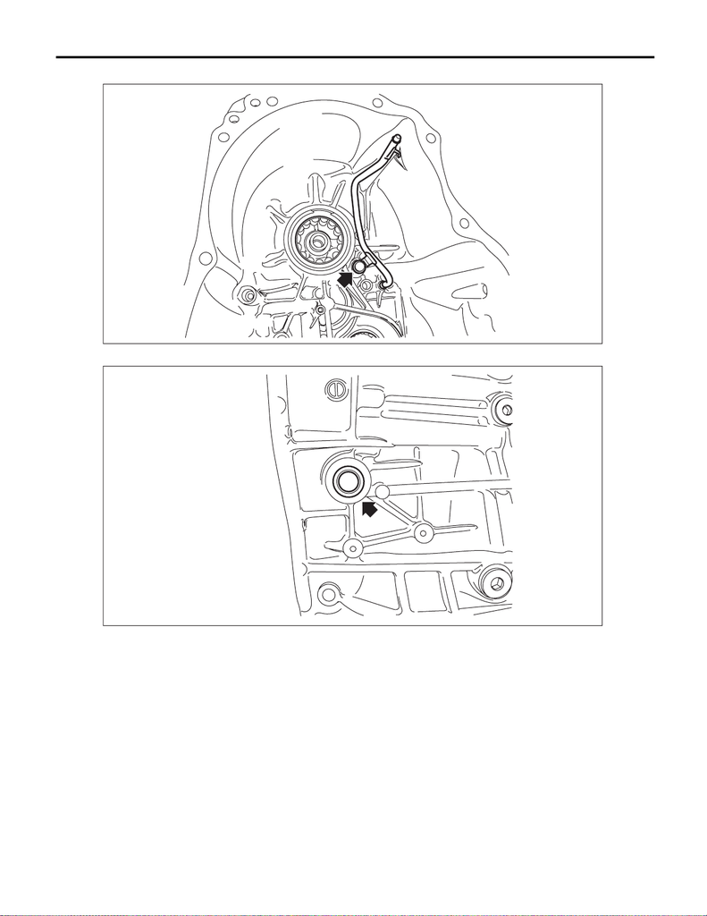

CVT(TR690)-218

Transmission Case

CONTINUOUSLY VARIABLE TRANSMISSION

3) Remove the lubrication pipe.

4) Remove the oil seal using a screwdriver wrapped with cloth etc.

AT-05284

AT-05285

15WRX_STI_US_EN.book 218 ページ ２０１５年２月１３日 金曜日 午前１１時２０分

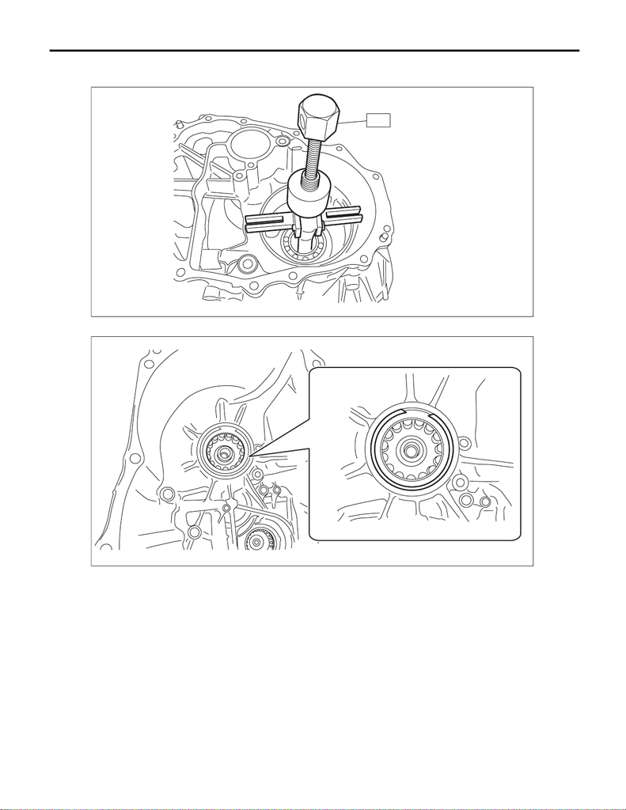

CVT(TR690)-219

Transmission Case

CONTINUOUSLY VARIABLE TRANSMISSION

5) Remove the ball bearing from reduction driven gear using ST.

ST 398527700 PULLER ASSY

6) Remove the snap ring on primary pulley side.

AT-05286

ST

AT-05287

15WRX_STI_US_EN.book 219 ページ ２０１５年２月１３日 金曜日 午前１１時２０分

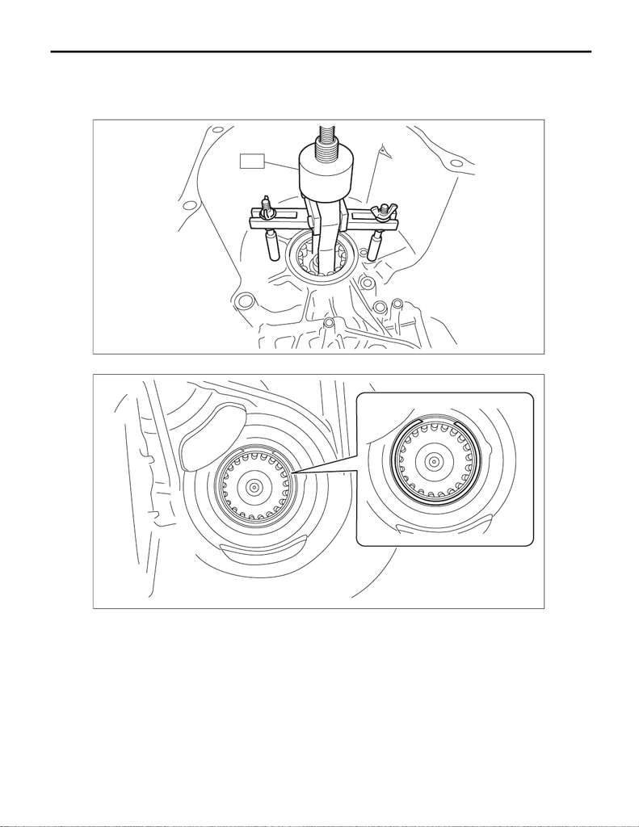

CVT(TR690)-220

Transmission Case

CONTINUOUSLY VARIABLE TRANSMISSION

7) Using the ST, remove the roller bearing on primary pulley side.

NOTE:

Warm up the bearing area of transmission case using a drier or heat gun.

ST 398527700 PULLER ASSY

8) Remove the snap ring on secondary pulley side.

AT-05288

ST

AT-05289

15WRX_STI_US_EN.book 220 ページ ２０１５年２月１３日 金曜日 午前１１時２０分

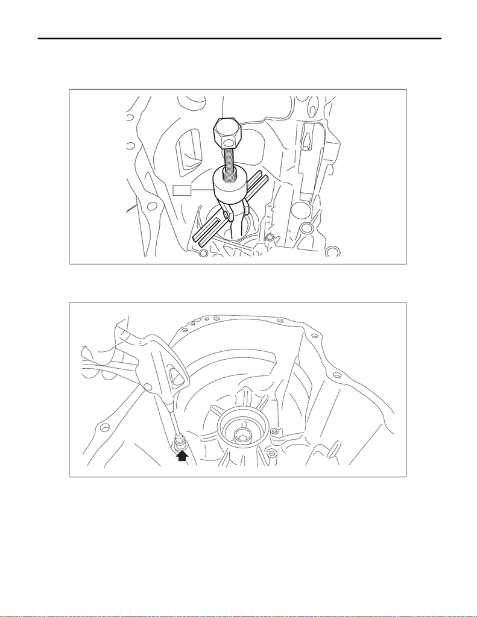

CVT(TR690)-221

Transmission Case

CONTINUOUSLY VARIABLE TRANSMISSION

9) Using the ST, remove the roller bearing on secondary pulley side.

NOTE:

Warm up the bearing area of transmission case using a drier or heat gun.

ST 398527700 PULLER ASSY

10) Remove the CVTF filter by blowing compressed air through the transmission case hole.

NOTE:

Hold the CVTF filter with a finger to prevent compressed air from leaking.

AT-05290

ST

CVT00581

15WRX_STI_US_EN.book 221 ページ ２０１５年２月１３日 金曜日 午前１１時２０分

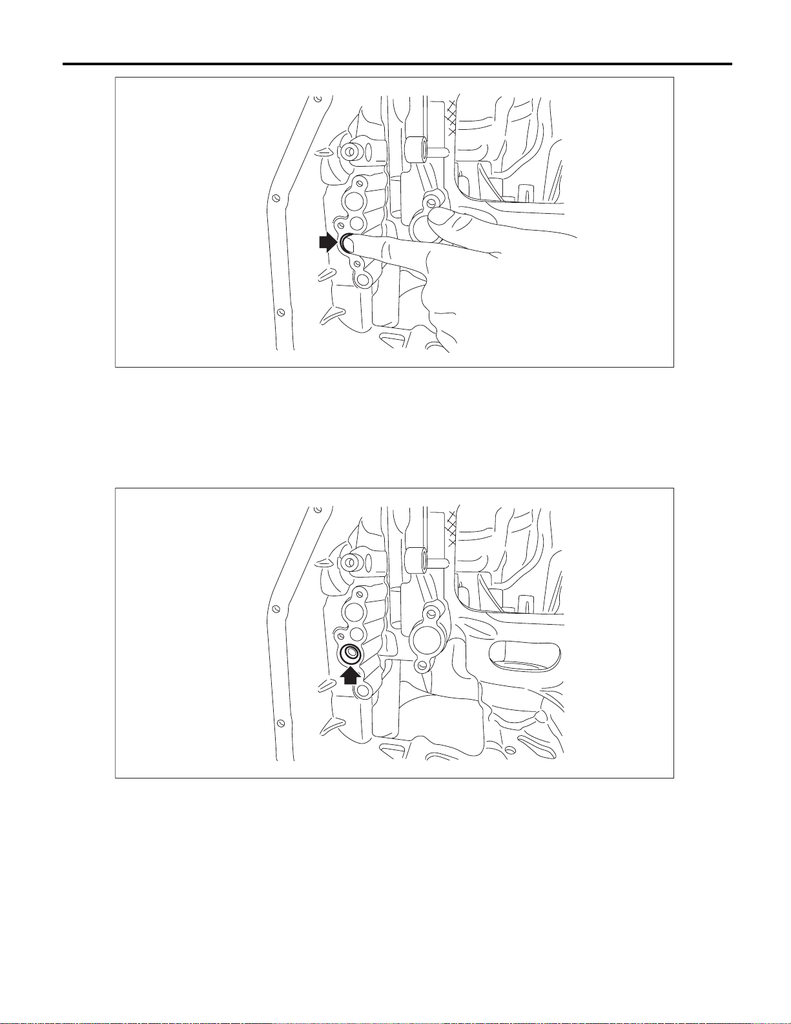

CVT(TR690)-222

Transmission Case

CONTINUOUSLY VARIABLE TRANSMISSION

D: ASSEMBLY

1) Install the CVTF filter.

NOTE:

• Use a new CVTF filter.

• Apply CVTF to the CVTF filter.

• Make sure that the CVTF filter does not protrude from the transmission case.

CVT00583

CVT00582

15WRX_STI_US_EN.book 222 ページ ２０１５年２月１３日 金曜日 午前１１時２０分

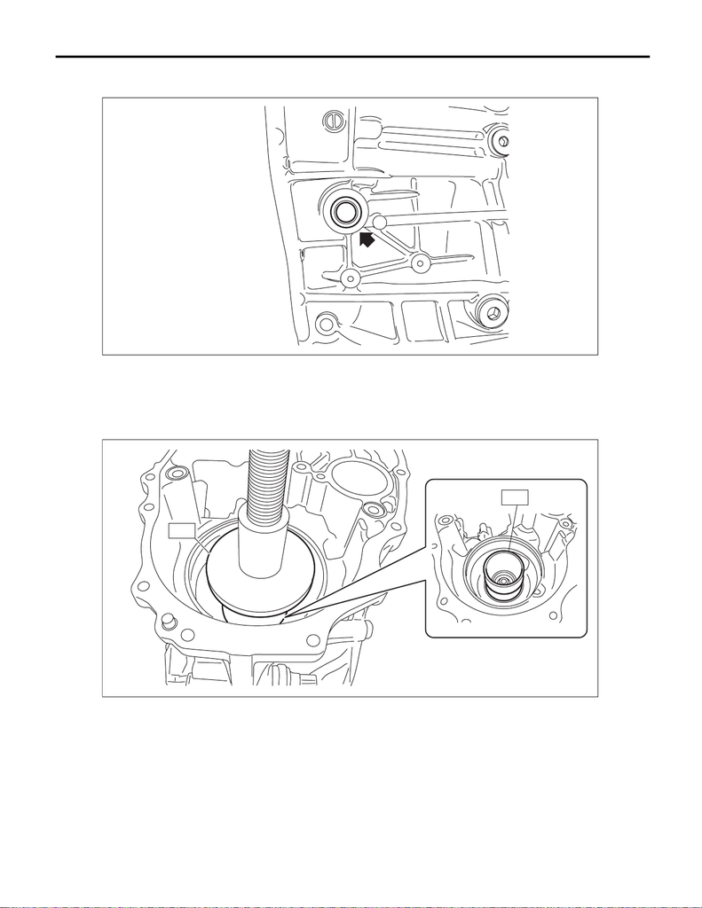

CVT(TR690)-223

Transmission Case

CONTINUOUSLY VARIABLE TRANSMISSION

2) Using the ST, install the oil seal.

ST 18657AA000 INSTALLER

3) Using ST1 and ST2, install the ball bearing on the reduction gear side.

NOTE:

Use a new ball bearing.

ST1 398177700 INSTALLER

ST2 499755602 PRESS SNAP RING

AT-05285

AT-05291

ST1

ST2

15WRX_STI_US_EN.book 223 ページ ２０１５年２月１３日 金曜日 午前１１時２０分

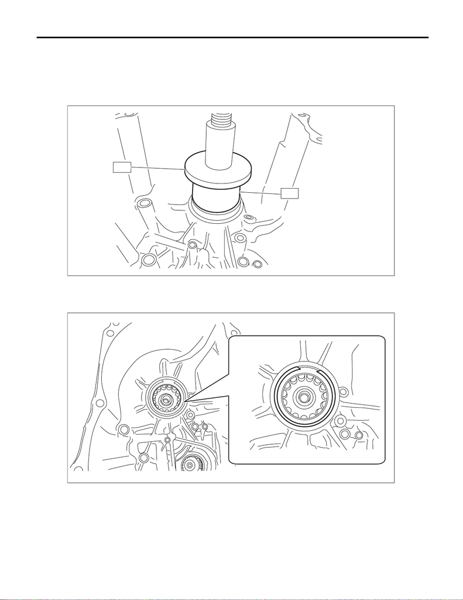

CVT(TR690)-224

Transmission Case

CONTINUOUSLY VARIABLE TRANSMISSION

4) Using ST1 and ST2, install the roller bearing on primary pulley side.

NOTE:

• Use a new roller bearing.

• Make adjustment so that the press gets in contact with the center of ST2.

ST1 398177700 INSTALLER

ST2 20299AG010 PRESS SNAP RING

5) Install the snap ring on primary pulley side.

NOTE:

Use new snap rings.

AT-05292

ST1

ST2

AT-05287

15WRX_STI_US_EN.book 224 ページ ２０１５年２月１３日 金曜日 午前１１時２０分

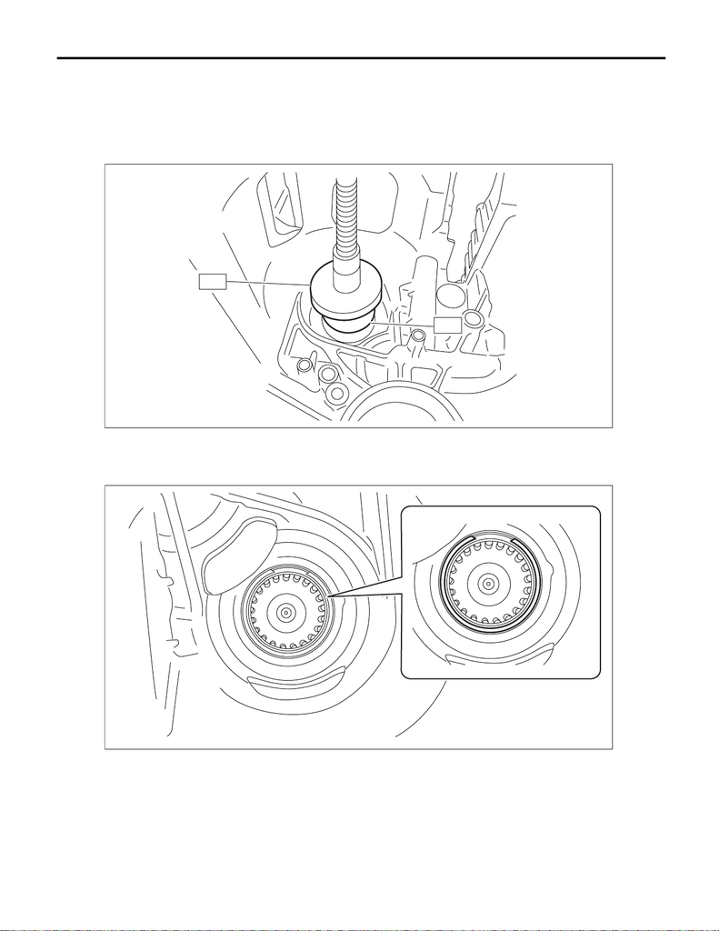

CVT(TR690)-225

Transmission Case

CONTINUOUSLY VARIABLE TRANSMISSION

6) Using ST1 and ST2, install the roller bearing on secondary pulley side.

NOTE:

• Use a new roller bearing.

• Make adjustment so that the press gets in contact with the center of ST2.

ST1 398177700 INSTALLER

ST2 499755602 PRESS SNAP RING

7) Install the snap ring on secondary pulley side.

NOTE:

Use new snap rings.

AT-05293

ST1

ST2

AT-05289

15WRX_STI_US_EN.book 225 ページ ２０１５年２月１３日 金曜日 午前１１時２０分

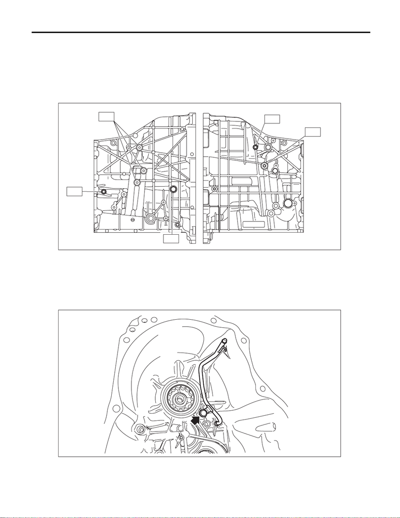

CVT(TR690)-226

Transmission Case

CONTINUOUSLY VARIABLE TRANSMISSION

8) Install all plugs.

NOTE:

Use new gaskets and O-rings.

T1: 13 N·m (1.3 kgf-m, 9.6 ft-lb)

T2: 25 N·m (2.5 kgf-m, 18.4 ft-lb)

9) Install the lubrication pipe and O-ring.

NOTE:

• Use new O-rings.

• Apply CVTF to the O-rings.

Tightening torque:

16 N·m (1.6 kgf-m, 11.8 ft-lb)

AT-05294

T1

T2

T3

T1

T2

AT-05284

15WRX_STI_US_EN.book 226 ページ ２０１５年２月１３日 金曜日 午前１１時２０分

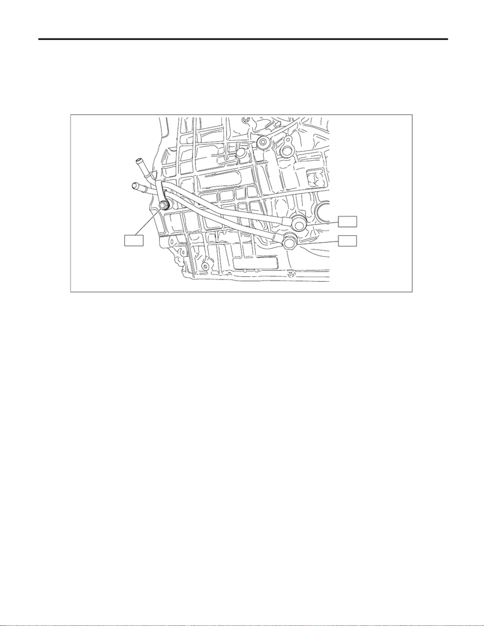

CVT(TR690)-227

Transmission Case

CONTINUOUSLY VARIABLE TRANSMISSION

10) Install the CVTF inlet pipe and CVTF outlet pipe.

NOTE:

Use a new gasket.

Tightening torque:

T1: 16 N·m (1.6 kgf-m, 11.8 ft-lb)

T2: 40 N·m (4.1 kgf-m, 29.5 ft-lb)

E: INSPECTION

• Check the transmission case for damage.

• Check for leakage of CVTF from the connection between converter case and transmission case.

• Check for leakage of CVTF from the connection between intermediate case and transmission case.

• Check the lubrication pipe for bend or damage.

• Check the bearing for smooth operation.

• Check the bearing for seizure or wear.

F: ADJUSTMENT

NOTE:

When replacing the transmission case with a new part, perform the following check and adjustment for the

selection.

• Select the thrust bearing for the forward clutch assembly. <Ref. to CVT(TR690)-199, ADJUSTMENT, For-

ward Clutch Assembly.>

• Select the snap ring for the reduction gear. <Ref. to CVT(TR690)-207, ADJUSTMENT, Reduction Driven

Gear.>

CVT00589

T2

T2

T1

15WRX_STI_US_EN.book 227 ページ ２０１５年２月１３日 金曜日 午前１１時２０分